# Red mullet in northern Spain (GSA 6) and the Adriatic (GSAs 17-18)

A spatio-temporal species distribution model: biomass, habitat suitability, trawling and marine heatwaves

climate-env-ais working group

21 October 2026

## How we worked

1 · Working group

Scientists around a table

The whole group or subgroups design and run the analyses together

➜

2 · Google Drive

Shared analyses

Scripts, data and figures are shared as they are produced

➜

3 · Curation

Read, clean, organise

Théophile and Claude review the Drive, fix paths and code, reproduce results

➜

4 · GitHub

Commit and push

Every change is versioned in one repository

➜

5 · Quarto report

Reproducible report

Methods, results and discussion points; archives all the analyses

➜

6 · Quarto slides

This presentation

Reads the report's figures and numbers, so it updates with it

➜

7 · Online

Published

Report, slides and code on GitHub Pages

Discussion points go back to the group for the next round of analyses

All analyses are **saved**, **archived**, **organised**, **committed**, **pushed** and **published online**.

## Aims and data

**Aims**

- Describe red mullet (*Mullus barbatus*) **biomass in space and time** in two areas
- Express **habitat suitability on a 0-1 scale**
- Then relate it to **trawling effort** (GFW AIS) and **marine heatwaves**

**Data decisions**

- Response: **biomass** (kg/km²) per MEDITS haul
- **2014-2021**: no Croatian MEDITS survey in 2012-2013 (also avoids the early AIS ramp-up)
- Two covariates only: **bottom temperature** (Copernicus, matched to each haul) and **depth**

617 valid hauls, GSA 6 (northern Spain)

1,631 valid hauls, GSAs 17-18 (Adriatic)

Red mullet absent from 17% of GSA 6 hauls and 11% of Adriatic hauls.

**Discussion point:** two thin years: GSA 6 in **2020** (39 hauls, COVID-19) and the Adriatic in **2017** (61 hauls).

## The model: sdmTMB

log(biomass) = **bottom temperature + depth** + **ω** (spatial) + **ε** (spatio-temporal, AR(1) by year)

- **Tweedie** observation model: zeros and skewed catches in one distribution
- **ω**: persistent hotspots not explained by the covariates
- **ε**: year-to-year departures from that pattern, correlated between years
- Fitted separately in each area on an SPDE mesh (184 and 414 vertices)

|  | GSA 6 | GSAs 17-18 |
| --- | --- | --- |
| Per +100 m depth | −94% | −68% |
| Per +1 °C bottom temp. | +18% | +17% |
| Spatial range | 86 km | 151 km |
| Largest \|ε\| | 0.7 | 2.9 |

Change in predicted biomass per unit of each covariate, on the response scale.

## Goodness of fit

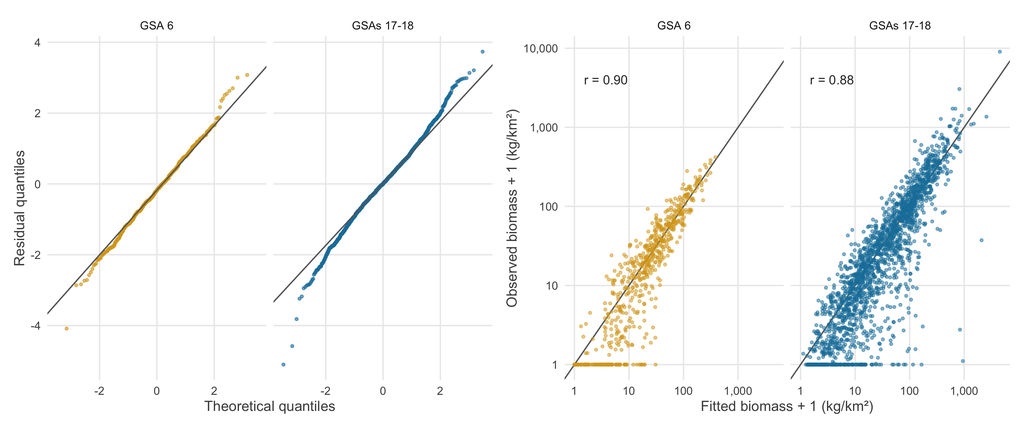

- Both models **converge** (all `sanity()` checks passed)
- Residuals on the normal line: **Tweedie** fits zeros and large catches
- Observed vs fitted (log): **r = 0.90** (GSA 6), **0.88** (Adriatic)
- In-sample fit; **cross-validation** would test new hauls

## Bottom temperature: two areas compared

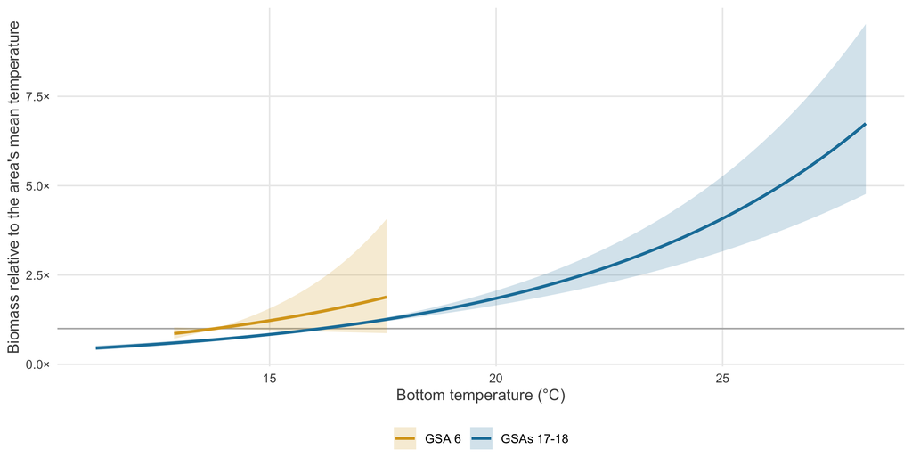

+17% biomass per +1 °C in the Adriatic (95% CI +14% to +21%)

+18% per +1 °C in GSA 6 (95% CI −4% to +45%): not significant

**Discussion point:** GSA 6 hauls span only 12.9-17.6 °C (Adriatic 11.2-28.2 °C), so the temperature effect is poorly constrained there and depth dominates.

## Predicted biomass: GSA 6

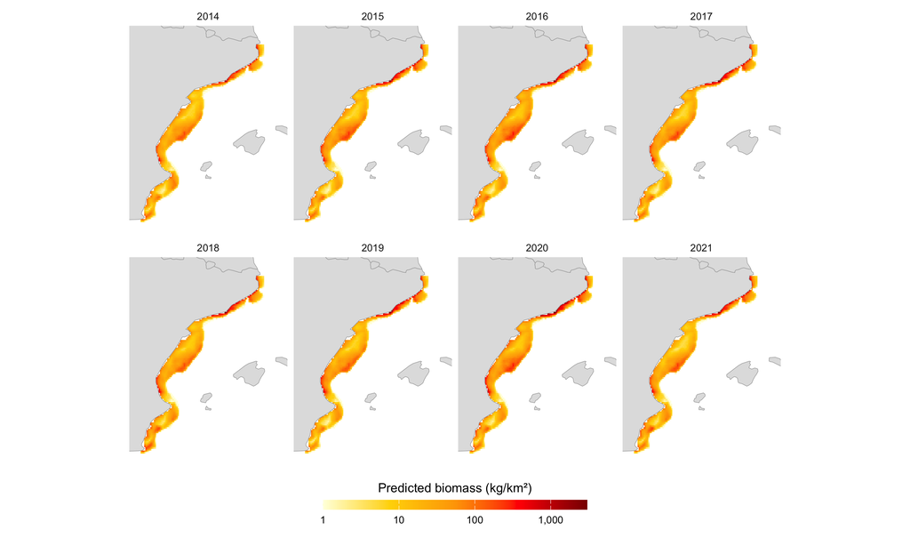

Highest on the inner shelf along the whole coast, dropping quickly offshore.

## Predicted biomass: Adriatic

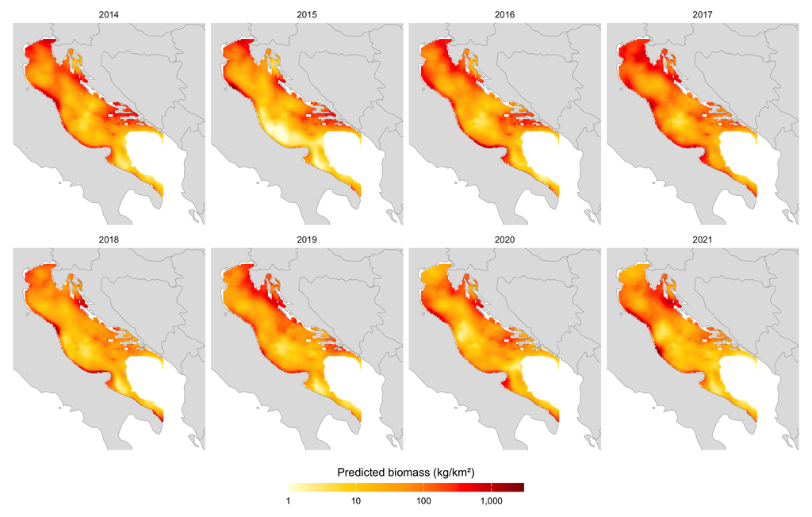

Highest in the shallow northern basin and along the Croatian coast; a gentler depth gradient over a much wider shelf.

## Spatial and spatio-temporal random effects

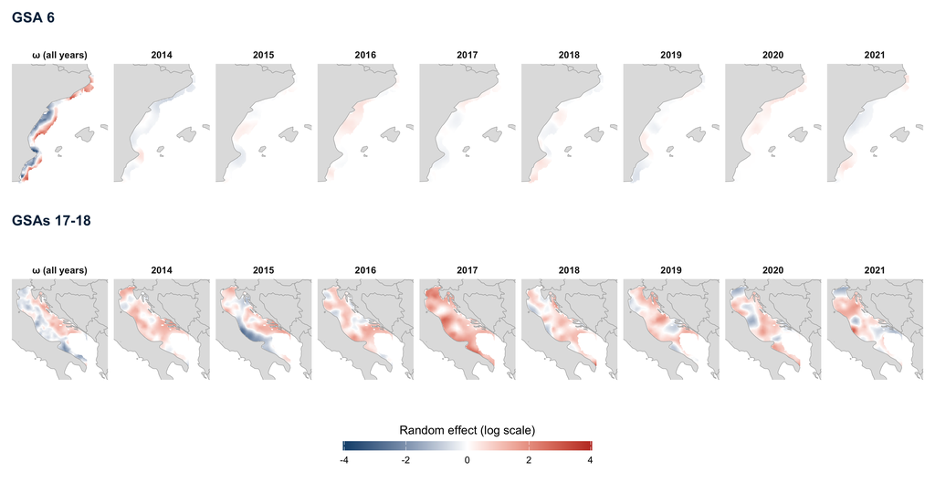

**ω** (first column): persistent hotspots not explained by depth and temperature

**ε** by year: small in GSA 6, large in the Adriatic (up to ±2.9, a factor of ~18 in biomass)

## Biomass index

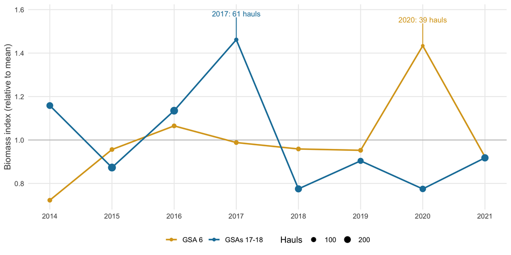

Sum of predicted biomass × cell area, per year

−3% GSA 6, 2015 → 2021 (Tweedie GAM of Section 2b: −12% in density)

77% to 146% The Adriatic index fluctuates more, between 77% and 146% of its 2014-2021 mean

**Discussion point:** each area peaks in its **least-sampled year**. Index standard errors (`get_index()`) would show how uncertain these years are.

## Habitat suitability index (HSI)

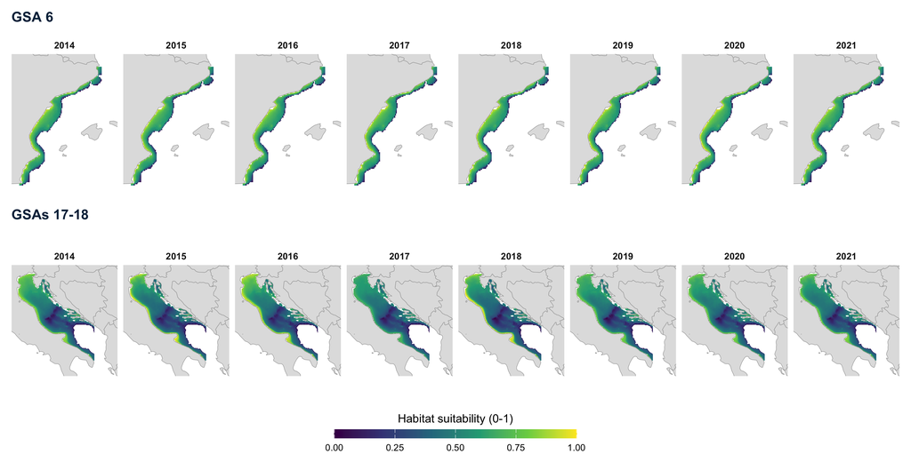

Fixed effects (depth + bottom temperature) rescaled to 0-1 across all years in each area; reproduces the group’s maps. Highest on the shallow inner shelf; in the Adriatic, the northern basin scores high almost everywhere.

## Change in habitat suitability, 2014 to 2021

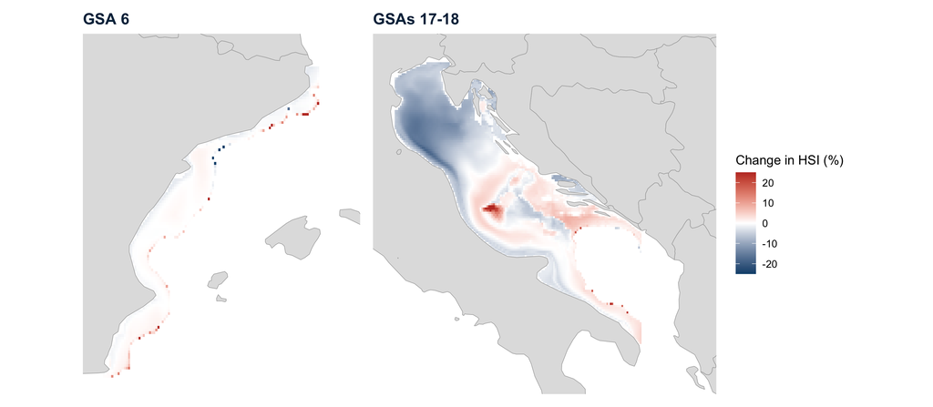

- GSA 6: median **+0.1%**, almost no change
- Adriatic: median **−1.8%**; 63% of cells lose suitability, mainly the northern basin

**Discussion point:** the % change of a 0-1 index explodes where HSI ≈ 0 (up to +217% in one GSA 6 cell): use the **difference in HSI** and a **2014-2021 trend** rather than two years.

## Overlap between red mullet and trawling

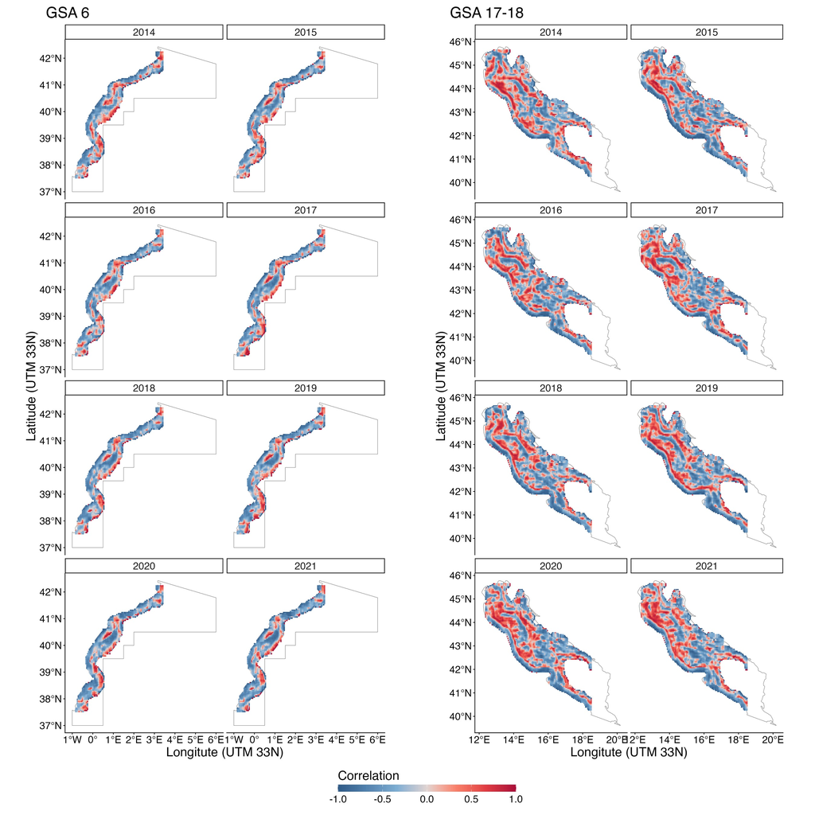

Local correlation between red mullet and **GFW trawling effort**, by year

- **Red**: trawling concentrated where red mullet is abundant
- GSA 6: mostly negative, positive patches on the outer shelf
- Adriatic: a positive band through the north-western and central basin every year; coastal edge negative

**Discussion point:** in small windows, correlations near ±1 are common by chance: add a **significance test** or a **whole-area overlap measure**.

## Marine heatwaves in the two areas

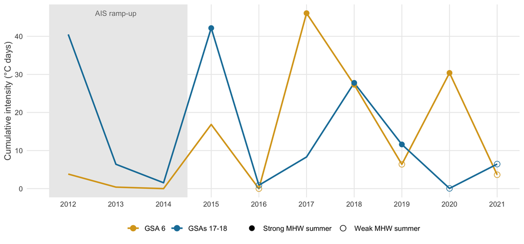

Summer heatwaves (Hobday et al. 2016) computed on the prediction grid of each area

- **GSA 6** strongest summers: **2017, 2018, 2020**
- **Adriatic** strongest summers: **2015, 2018, 2019**

**Discussion point:** the two areas do not share their heatwave years (2020: strong in GSA 6, almost none in the Adriatic), so comparisons need area-specific years.

## Heatwaves, biomass trends and trawling trends: GSA 6

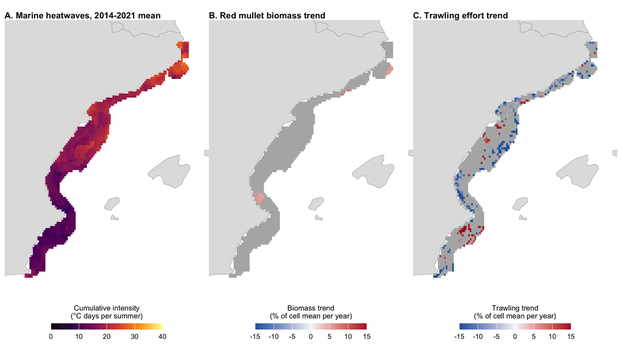

Trends 2014-2021 per cell, as % of the cell’s mean per year; grey: not significant (p ≥ 0.05). Significant biomass trends: 3% of cells; none after correcting for multiple tests.

## Heatwaves, biomass trends and trawling trends: Adriatic

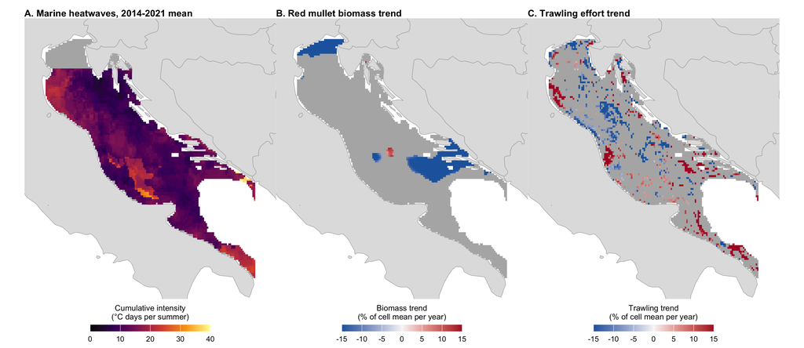

Grey in A: no SST data north of 45°N. Significant biomass trends: 12% of cells; none after correcting for multiple tests.

## Trawling in strong and weak heatwave summers

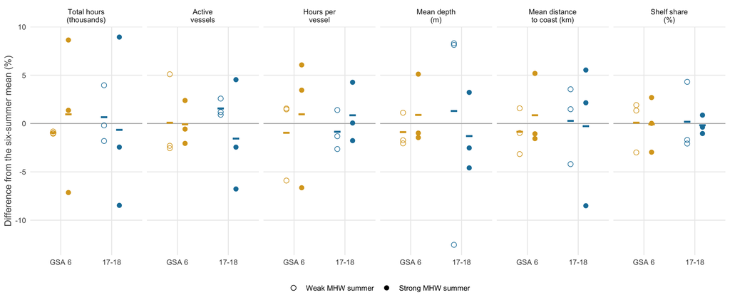

- Daily GFW trawler effort, June-August, 3 strong vs 3 weak summers, **from 2015**
- Total hours: **+1.9%** in GSA 6, **-1.3%** in the Adriatic, within year-to-year noise

## Do the fleets fish the same grounds?

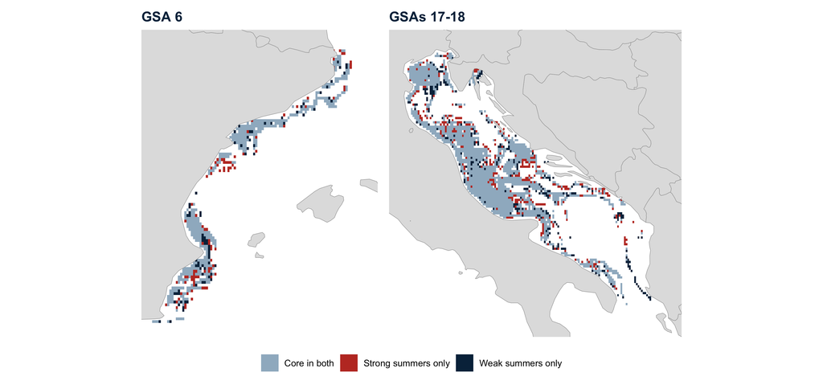

Core grounds (cells with 80% of hours): blue-grey in both types of summer, red strong only, dark blue weak only.

|  | GSA 6 | Adriatic |
| --- | --- | --- |
| Overlap D, strong vs weak | 0.72 | 0.72 |
| Overlap D, same type | 0.71, 0.7 | 0.71, 0.72 |
| Centre shift | 1.4 km | 3.9 km |
| Effort on red mullet hotspots | 13% / 14% | 23% / 20% |

**Same grounds** in strong and weak heatwave summers: overlap as high as between two summers of the same type (D: 1 = identical effort distribution).

## Heatwaves and red mullet biomass across years

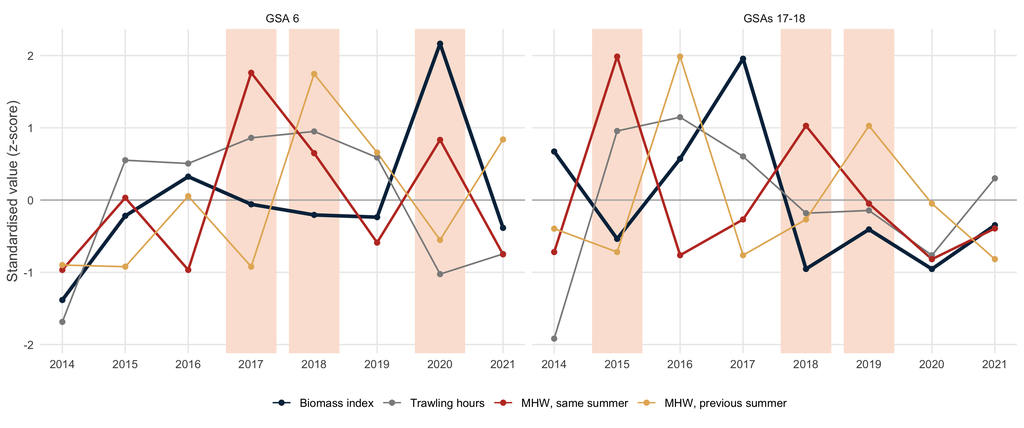

**Adriatic:** biomass drops in the two strongest heatwave summers (2015, 2018), recovers the year after; overall ρ = -0.14

**GSA 6:** the opposite, its strongest heatwave summers are among its higher-biomass years (ρ = 0.53)

**Discussion point:** eight years per area, two areas in opposite directions: a hypothesis to test, not a result.

## Heatwaves and red mullet biomass within years

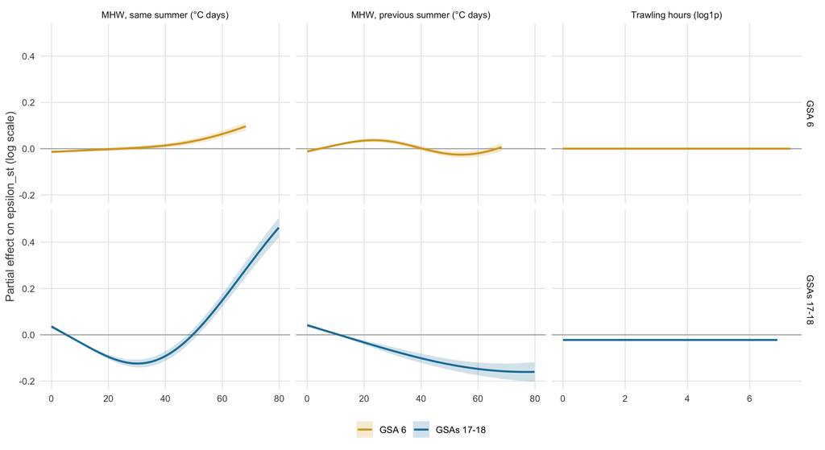

Year-specific deviation of predicted biomass (ε) in each cell, against heatwaves and trawling, with depth, latitude and year in the model

- **GSA 6:** small effects
- **Adriatic:** not monotonic, a dip at moderate heat, higher biomass in the hottest cells
- **No trawling effect** in either area
- Does not reproduce the annual dips

## Next steps

- Index **standard errors** with `get_index()`, especially for the thinly sampled years
- **Cross-validation** to test predictive skill
- Add an **intercept or year effects** to the model formula
- Habitat change as an **HSI difference or 2014-2021 trend**, rather than % change between two years
- Overlap with trawling: **significance** and a single summary per area and year
- Heatwaves: compare effort on **heatwave days vs other days** of the same summers; add heatwave intensity or a **bottom temperature anomaly** as a covariate of the model

## Slides, report and code

**These slides**

theophilemt92.github.io/gfw-med-data-lab/  
climate-env-ais/Quarto_slides_2C_red_mullet.html

**Full report** (Section 2c)

theophilemt92.github.io/gfw-med-data-lab/  
climate-env-ais/Quarto_report_CLIMATE-ENV-AIS.html

**Code**

github.com/TheophileMt92/  
gfw-med-data-lab

MEDITS from JRC; environment from Copernicus Marine; trawling effort from Global Fishing Watch. Figures and numbers from the report rendered 22 Oct 2026, 11:34.

Global Fishing Watch Mediterranean Data Lab · climate-env-ais · Section 2c